# Reproducible research assignment Document

Mohamed Chenini

November 9, 2017

## set the working directory

```r
setwd("~/DS/reproducible-research-Week2-Project")
```

## unzip the input data file

```r
if(!file.exists("activity.csv"))
{
    unzip("repdata%2Fdata%2Factivity.zip")
}
```

### read the activity file into a data frame

```r
activityData <- read.csv(file = "activity.csv", header = TRUE)
activityData$date <- as.Date(activityData$date, "%Y-%m-%d")
```

### get info on the activityData data frame

```r
str(activityData)
```

```
## 'data.frame':    17568 obs. of  3 variables:
##  $ steps   : int  NA NA NA NA NA NA NA NA NA NA ...
##  $ date    : Date, format: "2012-10-01" "2012-10-01" ...
##  $ interval: int  0 5 10 15 20 25 30 35 40 45 ...
```

### Get a summary of the data

```r
summary(activityData)
```

```
##      steps             date               interval
##  Min.   :  0.00   Min.   :2012-10-01   Min.   :   0.0
##  1st Qu.:  0.00   1st Qu.:2012-10-16   1st Qu.: 588.8
##  Median :  0.00   Median :2012-10-31   Median :1177.5
##  Mean   : 37.38   Mean   :2012-10-31   Mean   :1177.5
##  3rd Qu.: 12.00   3rd Qu.:2012-11-15   3rd Qu.:1766.2
##  Max.   :806.00   Max.   :2012-11-30   Max.   :2355.0
##  NA's   :2304
```

### check the class of the date column and convert it to a Data class

```r
activityData$date <-  as.Date(activityData$date, format = "%Y-%m-%d")
class(activityData$date)
```

```
## [1] "Date"
```

```r
dailyStepSum <- tapply(activityData$steps, activityData$date, sum, na.rm = TRUE)
```

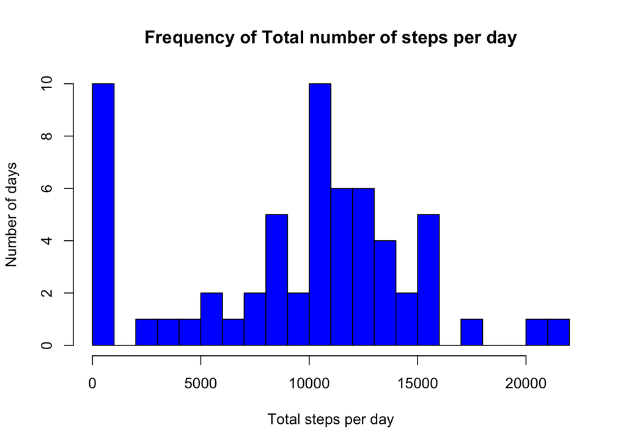

```r
histData <- tapply(activityData$steps, activityData$date, sum, na.rm = TRUE)
hist(histData, breaks = 19, col = "blue", xlab = "Total steps per day", ylab = "Number of days", main = "Frequency of Total number of steps per day")
```

### mean and median

```r
meanDataByInterval <- mean(histData, na.rm = TRUE)
medianDataByInterval <- median(histData, na.rm=TRUE)
```

```r
fiveMinSteps <- aggregate(steps ~ interval, data = activityData, FUN =mean)
head(fiveMinSteps)
```

```
##   interval     steps
## 1        0 1.7169811
## 2        5 0.3396226
## 3       10 0.1320755
## 4       15 0.1509434
## 5       20 0.0754717
## 6       25 2.0943396
```

### Average daily activity pattern - time series plot

### 5-minute interval, on average across all the days in the dataset, that contains the maximum number of steps?

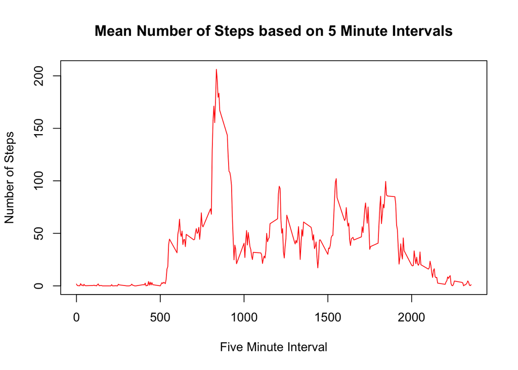

```r
stepsIntervalMean <- tapply(activityData$steps, as.factor(activityData$interval), mean, na.rm = TRUE)
plot(levels(as.factor(activityData$interval)), stepsIntervalMean, type = "l", xlab = "Five Minute Interval",
     ylab = "Number of Steps", main = "Mean Number of Steps based on 5 Minute Intervals", col = "red")
```

```r
stepsIntervalMax <- which.max(stepsIntervalMean)
intervalMax <- as.numeric(levels(as.factor(activityData$interval)))[stepsIntervalMax]
intervalMax
```

```
## [1] 835
```

### Which 5-minute interval, on average across all the days in the dataset, contains the maximum number of steps?

```r
stepsMax <- as.numeric(stepsIntervalMean[stepsIntervalMax])
stepsMax
```

```
## [1] 206.1698
```

## Imputing missing values

### Calculate and report the total number of missing values in the dataset (i.e. the total number of rows with 𝙽𝙰s)

```r
nbrNAs <- nrow(activityData[!complete.cases(activityData), ])
nbrNAs
```

```
## [1] 2304
```

### Clean the data

```r
cleanData <- na.omit(activityData)
```

```r
library(dplyr)
dataByDay <- group_by(cleanData, date)
```

### Get a summary of the data

```r
summary(dataByDay)
```

```
##      steps             date               interval
##  Min.   :  0.00   Min.   :2012-10-02   Min.   :   0.0
##  1st Qu.:  0.00   1st Qu.:2012-10-16   1st Qu.: 588.8
##  Median :  0.00   Median :2012-10-29   Median :1177.5
##  Mean   : 37.38   Mean   :2012-10-30   Mean   :1177.5
##  3rd Qu.: 12.00   3rd Qu.:2012-11-16   3rd Qu.:1766.2
##  Max.   :806.00   Max.   :2012-11-29   Max.   :2355.0
```

### Devise a strategy for filling in all of the missing values in the dataset.

```r
library(dplyr)
replaceWithMean <- function(num) replace(num, is.na(num), mean(num, na.rm = TRUE))
dataComplete <- (activityData %>% group_by(interval) %>% mutate(steps = replaceWithMean(steps)))
head(dataComplete)
```

```
## # A tibble: 6 x 3
## # Groups:   interval [6]
##       steps       date interval
##       <dbl>     <date>    <int>
## 1 1.7169811 2012-10-01        0
## 2 0.3396226 2012-10-01        5
## 3 0.1320755 2012-10-01       10
## 4 0.1509434 2012-10-01       15
## 5 0.0754717 2012-10-01       20
## 6 2.0943396 2012-10-01       25
```

### Verify no more NA in dataComplete

```r
sum(is.na(dataComplete))
```

```
## [1] 0
```

### Create a new dataset that is equal to the original dataset but with the missing data filled in.

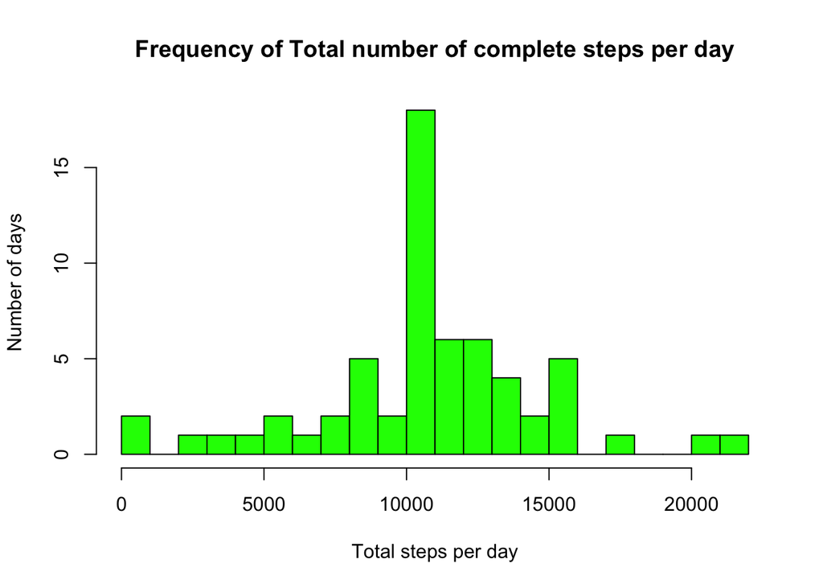

```r
cleanDataComplete <- tapply(dataComplete$steps, dataComplete$date, sum, na.rm = TRUE)
hist(cleanDataComplete, breaks = 19, col = "green", xlab = "Total steps per day", ylab = "Number of days", main = "Frequency of Total number of complete steps per day")
```

### Calculate the mean and median total number of steps taken per day of the new complete clean data

```r
stepsCompleteMean <- mean(cleanDataComplete, na.rm = TRUE)
stepsCompleteMean
```

```
## [1] 10766.19
```

```r
stepsCompleteMedian <- median(cleanDataComplete, na.rm = TRUE)
stepsCompleteMedian
```

```
## [1] 10766.19
```

### Do these values differ from the estimates from the first part of the assignment?

### Before cleaning

```r
meanDataByInterval
```

```
## [1] 9354.23
```

```r
medianDataByInterval
```

```
## [1] 10395
```

### After cleaning

```r
stepsCompleteMean
```

```
## [1] 10766.19
```

```r
stepsCompleteMedian
```

```
## [1] 10766.19
```

## Are there differences in activity patterns between weekdays and weekends?

### Create a new factor variable in the dataset with two levels – “weekday” and “weekend” indicating whether a given date is a weekday or weekend day.

```r
dataComplete$day <- ifelse(weekdays(dataComplete$date) %in% c("Saturday", "Sunday"), "weekend", "weekday")
```

### display

```r
head(dataComplete)
```

```
## # A tibble: 6 x 4
## # Groups:   interval [6]
##       steps       date interval     day
##       <dbl>     <date>    <int>   <chr>
## 1 1.7169811 2012-10-01        0 weekday
## 2 0.3396226 2012-10-01        5 weekday
## 3 0.1320755 2012-10-01       10 weekday
## 4 0.1509434 2012-10-01       15 weekday
## 5 0.0754717 2012-10-01       20 weekday
## 6 2.0943396 2012-10-01       25 weekday
```

### Make a panel plot containing a time series plot (i.e. 𝚝𝚢𝚙𝚎 = “𝚕”) of the 5-minute interval (x-axis) and the average number of steps taken, averaged across all weekday days or weekend days (y-axis).

```r
wday <- subset(dataComplete, day == "weekday")
wday.steps <- aggregate(wday$steps, list(wday$interval), mean)
wday.steps$day <- "Weekday"
colnames(wday.steps) <- c("Interval", "Mean.Steps", "day")

wend <- subset(dataComplete, day == "weekend")
wend.steps <- aggregate(wend$steps, list(wend$interval), mean)
wend.steps$day <- "Weekend"
colnames(wend.steps) <- c("Interval", "Mean.Steps", "day")

activity.data.weekday <- rbind(wday.steps, wend.steps)
```

### The two Time Series plots

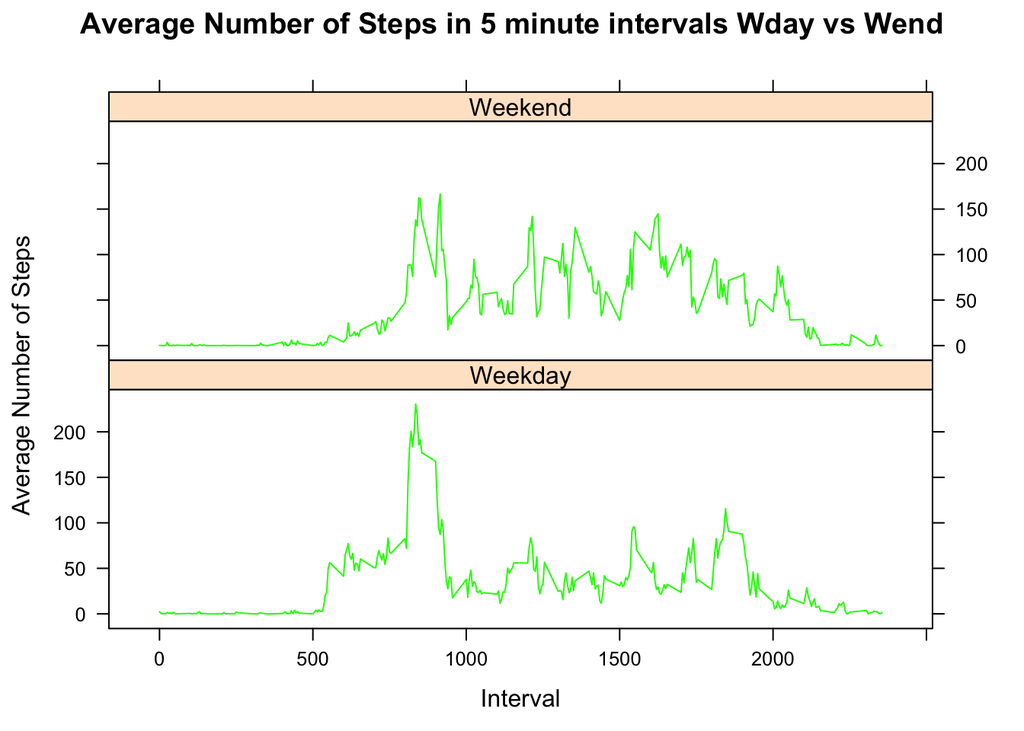

```r
library(lattice)
xyplot(Mean.Steps ~ Interval | day, activity.data.weekday, type = "l", layout = c(1,2),
       ylab = "Average Number of Steps", main = "Average Number of Steps in 5 minute intervals Wday vs Wend", col = "green")
```

### There are some differences at the beginning of the graphs between weekdays and weekends.